# Проект: Принятие решения в бизнесе

# Описание проекта, необходимых шагов и данных

## Описание проекта

Мы выступаем в роли аналитика крупного интернет-магазина. Вместе с отделом маркетинга мы подготовили список гипотез для увеличения выручки.

Нам необходимо:

- Приоритизировать гипотезы;
- Запустить `A/B-тест` и проанализировать результаты

В нашем распоряжении датасеты с:

- Гипотезами;
- Заказами;
- Визитами

## Необходимые шаги

**Шаг 1. Обзор и предобработка данных**

**Шаг 2. Приоритизация гипотез**

Задачи:

- Применить фреймворк `ICE` для приоритизации гипотез;
- Применить фреймворк `RICE` для приоритизации гипотез;
- Указать, как изменилась приоритизация гипотез при применении `RICE` вместо `ICE`. Объяснить, почему так произошло.

**Шаг 3. Анализ A/B-теста**

Задачи:

- Построить график кумулятивной выручки по группам;
- Построить график кумулятивного среднего чека по группам;
- Построить график относительного изменения кумулятивного среднего чека группы B к группе A;
- Построить график кумулятивного среднего количества заказов на посетителя по группам;
- Построить график относительного изменения кумулятивного среднего количества заказов на посетителя группы B к группе A;
- Построить точечный график количества заказов по пользователям;
- Посчитать 95-й и 99-й перцентили количества заказов на пользователя. Выбрать границу для определения аномальных пользователей;
- Построить точечный график стоимостей заказов;
- Посчитать 95-й и 99-й перцентили стоимости заказов. Выбрать границу для определения аномальных заказов.
- Посчитать статистическую значимость различий в среднем количестве заказов на посетителя между группами по «сырым» данным;
- Посчитать статистическую значимость различий в среднем чеке заказа между группами по «сырым» данным;
- Посчитать статистическую значимость различий в среднем количестве заказов на посетителя между группами по «очищенным» данным;
- Посчитать статистическую значимость различий в среднем чеке заказа между группами по «очищенным» данным;
- Принять решение по результатам теста и объяснить. Варианты решений:
  1. Остановить тест, зафиксировать победу одной из групп.
  2. Остановить тест, зафиксировать отсутствие различий между группами.
  3. Продолжить тест.

**Шаг 4. Сделать общий вывод**

## Описание данных

В нашем распоряжении три датасета:

Структура `hypothesis.csv`:

- `Hypothesis` — краткое описание гипотезы;
- `Reach` — охват пользователей по 10-балльной шкале;
- `Impact` — влияние на пользователей по 10-балльной шкале;
- `Confidence` — уверенность в гипотезе по 10-балльной шкале;
- `Efforts` — затраты ресурсов на проверку гипотезы по 10-балльной шкале. Чем больше значение `Efforts`, тем дороже проверка гипотезы.

Структура `orders.csv`:

- `transactionId` — идентификатор заказа;
- `visitorId` — идентификатор пользователя, совершившего заказ;
- `date` — дата, когда был совершён заказ;
- `revenue` — выручка заказа;
- `group` — группа A/B-теста, в которую попал заказ.

Структура `visitors.csv`:

- `date` — дата;
- `group` — группа A/B-теста;
- `visitors` — количество пользователей в указанную дату в указанной группе A/B-теста

# Обзор и предобработка данных

```python
# Импортируем необходимые библиотеки

import pandas as pd
import matplotlib.pyplot as plt
import scipy.stats as stats
import numpy as np
import datetime as dt
```

```python
# Для удобства отобразим все колонки таблицы и изменим их ширину

pd.set_option('display.max_columns', None)
pd.set_option('max_colwidth', None)
```

```python
# Прочитаем все датасеты и запишем их в отдельные перменные

hypothesis = pd.read_csv('hypothesis.csv')
orders = pd.read_csv('orders.csv')
visitors = pd.read_csv('visitors.csv')
```

```python
# Создадим функцию для обзора данных: выведем первые и последние 5 строк, общую информацию, количество и процент пропусков,
# кол-во дубликатов и статистические данные по датафрейму.
# Функция на вход будет принимать датафрейм.

def df_review(data):

    # Выведем первые и последние 5 строк из датафрейму
    print('{0:^125}'.format('Обзор данных датасета'))
    display(data)
    print('-'*120)

    # Выведем общую информацию по датафрейму
    print('{0:^125}'.format('Общая информация по датасету'),end='\n\n')
    data.info()
    print('-'*120)

    # Выведем кол-во и процент пропусков в колонках датафрейма
    print('{0:^125}'.format('Количество пропусков и их доля от всех строк в колонке'))
    # Посчитаем кол-во пропусков и их процент от общего числа строк в датафрейме по каждому столбцу
    num_of_nan = data.isnull().sum().to_frame().reset_index().merge \
    (round(data.isnull().mean()*100,2).to_frame().reset_index(), on='index', how='left')
    # Переимунуем названия колонок для удобства и выведем рез-т
    num_of_nan.columns = ['columns','nan_count','nan_ratio']
    display(num_of_nan.sort_values(by='nan_count', ascending=False))
    print('-'*120)

    # Посчитаем кол-во явных дубликатов в датафрейме
    print(f'Количество явных дубликатов в датасете: {data.duplicated().sum()}')
    print('-'*120,end='\n\n')

    # Выведем информацию по статистическим данным датафрейма
    print('{0:^125}'.format('Обзор cтатистических данных по датасету'))
    display(data.describe())
```

```python
df_review(hypothesis)
```

```
                                                    Обзор данных датасета
```

|  | Hypothesis | Reach | Impact | Confidence | Efforts |
| --- | --- | --- | --- | --- | --- |
| 0 | Добавить два новых канала привлечения трафика, что позволит привлекать на 30% больше пользователей | 3 | 10 | 8 | 6 |
| 1 | Запустить собственную службу доставки, что сократит срок доставки заказов | 2 | 5 | 4 | 10 |
| 2 | Добавить блоки рекомендаций товаров на сайт интернет магазина, чтобы повысить конверсию и средний чек заказа | 8 | 3 | 7 | 3 |
| 3 | Изменить структура категорий, что увеличит конверсию, т.к. пользователи быстрее найдут нужный товар | 8 | 3 | 3 | 8 |
| 4 | Изменить цвет фона главной страницы, чтобы увеличить вовлеченность пользователей | 3 | 1 | 1 | 1 |
| 5 | Добавить страницу отзывов клиентов о магазине, что позволит увеличить количество заказов | 3 | 2 | 2 | 3 |
| 6 | Показать на главной странице баннеры с актуальными акциями и распродажами, чтобы увеличить конверсию | 5 | 3 | 8 | 3 |
| 7 | Добавить форму подписки на все основные страницы, чтобы собрать базу клиентов для email-рассылок | 10 | 7 | 8 | 5 |
| 8 | Запустить акцию, дающую скидку на товар в день рождения | 1 | 9 | 9 | 5 |

```
------------------------------------------------------------------------------------------------------------------------
                                                Общая информация по датасету

<class 'pandas.core.frame.DataFrame'>
RangeIndex: 9 entries, 0 to 8
Data columns (total 5 columns):
 #   Column      Non-Null Count  Dtype
---  ------      --------------  -----
 0   Hypothesis  9 non-null      object
 1   Reach       9 non-null      int64
 2   Impact      9 non-null      int64
 3   Confidence  9 non-null      int64
 4   Efforts     9 non-null      int64
dtypes: int64(4), object(1)
memory usage: 488.0+ bytes
------------------------------------------------------------------------------------------------------------------------
                                   Количество пропусков и их доля от всех строк в колонке
```

|  | columns | nan_count | nan_ratio |
| --- | --- | --- | --- |
| 0 | Hypothesis | 0 | 0.0 |
| 1 | Reach | 0 | 0.0 |
| 2 | Impact | 0 | 0.0 |
| 3 | Confidence | 0 | 0.0 |
| 4 | Efforts | 0 | 0.0 |

```
------------------------------------------------------------------------------------------------------------------------
Количество явных дубликатов в датасете: 0
------------------------------------------------------------------------------------------------------------------------

                                           Обзор cтатистических данных по датасету
```

|  | Reach | Impact | Confidence | Efforts |
| --- | --- | --- | --- | --- |
| count | 9.000000 | 9.000000 | 9.000000 | 9.000000 |
| mean | 4.777778 | 4.777778 | 5.555556 | 4.888889 |
| std | 3.153481 | 3.192874 | 3.045944 | 2.803767 |
| min | 1.000000 | 1.000000 | 1.000000 | 1.000000 |
| 25% | 3.000000 | 3.000000 | 3.000000 | 3.000000 |
| 50% | 3.000000 | 3.000000 | 7.000000 | 5.000000 |
| 75% | 8.000000 | 7.000000 | 8.000000 | 6.000000 |
| max | 10.000000 | 10.000000 | 9.000000 | 10.000000 |

После обзора датафрейма, мы видим, что данные не нуждаются в особой преодобработке, только для удобства приведем названия колонок к нижнему регистру

```python
#Приведем к нижнему регистру названия колонок в таблице

hypothesis.columns = hypothesis.columns.str.lower()
```

```python
df_review(orders)
```

```
                                                    Обзор данных датасета
```

|  | transactionId | visitorId | date | revenue | group |
| --- | --- | --- | --- | --- | --- |
| 0 | 3667963787 | 3312258926 | 2019-08-15 | 1650 | B |
| 1 | 2804400009 | 3642806036 | 2019-08-15 | 730 | B |
| 2 | 2961555356 | 4069496402 | 2019-08-15 | 400 | A |
| 3 | 3797467345 | 1196621759 | 2019-08-15 | 9759 | B |
| 4 | 2282983706 | 2322279887 | 2019-08-15 | 2308 | B |
| ... | ... | ... | ... | ... | ... |
| 1192 | 2662137336 | 3733762160 | 2019-08-14 | 6490 | B |
| 1193 | 2203539145 | 370388673 | 2019-08-14 | 3190 | A |
| 1194 | 1807773912 | 573423106 | 2019-08-14 | 10550 | A |
| 1195 | 1947021204 | 1614305549 | 2019-08-14 | 100 | A |
| 1196 | 3936777065 | 2108080724 | 2019-08-15 | 202740 | B |

1197 rows × 5 columns

```
------------------------------------------------------------------------------------------------------------------------
                                                Общая информация по датасету

<class 'pandas.core.frame.DataFrame'>
RangeIndex: 1197 entries, 0 to 1196
Data columns (total 5 columns):
 #   Column         Non-Null Count  Dtype
---  ------         --------------  -----
 0   transactionId  1197 non-null   int64
 1   visitorId      1197 non-null   int64
 2   date           1197 non-null   object
 3   revenue        1197 non-null   int64
 4   group          1197 non-null   object
dtypes: int64(3), object(2)
memory usage: 46.9+ KB
------------------------------------------------------------------------------------------------------------------------
                                   Количество пропусков и их доля от всех строк в колонке
```

|  | columns | nan_count | nan_ratio |
| --- | --- | --- | --- |
| 0 | transactionId | 0 | 0.0 |
| 1 | visitorId | 0 | 0.0 |
| 2 | date | 0 | 0.0 |
| 3 | revenue | 0 | 0.0 |
| 4 | group | 0 | 0.0 |

```
------------------------------------------------------------------------------------------------------------------------
Количество явных дубликатов в датасете: 0
------------------------------------------------------------------------------------------------------------------------

                                           Обзор cтатистических данных по датасету
```

|  | transactionId | visitorId | revenue |
| --- | --- | --- | --- |
| count | 1.197000e+03 | 1.197000e+03 | 1.197000e+03 |
| mean | 2.155621e+09 | 2.165960e+09 | 8.348006e+03 |
| std | 1.229085e+09 | 1.236014e+09 | 3.919113e+04 |
| min | 1.062393e+06 | 5.114589e+06 | 5.000000e+01 |
| 25% | 1.166776e+09 | 1.111826e+09 | 1.220000e+03 |
| 50% | 2.145194e+09 | 2.217985e+09 | 2.978000e+03 |
| 75% | 3.237740e+09 | 3.177606e+09 | 8.290000e+03 |
| max | 4.293856e+09 | 4.283872e+09 | 1.294500e+06 |

Как и в предыдущем датафрейме, мы видим, что с данными все хорошо, за исключением неверного типа данных для колонки `date`, исправим это

```python
orders['date'] = pd.to_datetime(orders['date'])
```

```python
df_review(visitors)
```

```
                                                    Обзор данных датасета
```

|  | date | group | visitors |
| --- | --- | --- | --- |
| 0 | 2019-08-01 | A | 719 |
| 1 | 2019-08-02 | A | 619 |
| 2 | 2019-08-03 | A | 507 |
| 3 | 2019-08-04 | A | 717 |
| 4 | 2019-08-05 | A | 756 |
| ... | ... | ... | ... |
| 57 | 2019-08-27 | B | 720 |
| 58 | 2019-08-28 | B | 654 |
| 59 | 2019-08-29 | B | 531 |
| 60 | 2019-08-30 | B | 490 |
| 61 | 2019-08-31 | B | 718 |

62 rows × 3 columns

```
------------------------------------------------------------------------------------------------------------------------
                                                Общая информация по датасету

<class 'pandas.core.frame.DataFrame'>
RangeIndex: 62 entries, 0 to 61
Data columns (total 3 columns):
 #   Column    Non-Null Count  Dtype
---  ------    --------------  -----
 0   date      62 non-null     object
 1   group     62 non-null     object
 2   visitors  62 non-null     int64
dtypes: int64(1), object(2)
memory usage: 1.6+ KB
------------------------------------------------------------------------------------------------------------------------
                                   Количество пропусков и их доля от всех строк в колонке
```

|  | columns | nan_count | nan_ratio |
| --- | --- | --- | --- |
| 0 | date | 0 | 0.0 |
| 1 | group | 0 | 0.0 |
| 2 | visitors | 0 | 0.0 |

```
------------------------------------------------------------------------------------------------------------------------
Количество явных дубликатов в датасете: 0
------------------------------------------------------------------------------------------------------------------------

                                           Обзор cтатистических данных по датасету
```

|  | visitors |
| --- | --- |
| count | 62.000000 |
| mean | 607.290323 |
| std | 114.400560 |
| min | 361.000000 |
| 25% | 534.000000 |
| 50% | 624.500000 |
| 75% | 710.500000 |
| max | 770.000000 |

С данными все в порядке, но как и в таблице `orders` неверный тип данных колонки `date`, приведем его к нужному виду

```python
visitors['date'] = pd.to_datetime(visitors['date'])
```

В ходе обзора и предобработки данных мы:

- В датафрейме `hypothesis` привели к нижнему регистру названия колонок;
- В датафреймах `orders` и `visits` изменили тип данных в колонке `date`

# Приоритизация гипотез

## Применение фреймворка ICE

Для расчета `ICE` (от англ. `impact`, `confidence`, `effort` / `ease` «влияние, уверенность, усилия / простота») применяется следующая формула:

$$ICE = \frac{Impact * Confidence}{Efforts}$$

```python
# Рассчитаем ICE

hypothesis['ICE'] = round((hypothesis['impact'] * hypothesis['confidence']) / hypothesis['efforts'], 1)
hypothesis[['hypothesis','ICE']].sort_values(by='ICE',ascending = False)
```

|  | hypothesis | ICE |
| --- | --- | --- |
| 8 | Запустить акцию, дающую скидку на товар в день рождения | 16.2 |
| 0 | Добавить два новых канала привлечения трафика, что позволит привлекать на 30% больше пользователей | 13.3 |
| 7 | Добавить форму подписки на все основные страницы, чтобы собрать базу клиентов для email-рассылок | 11.2 |
| 6 | Показать на главной странице баннеры с актуальными акциями и распродажами, чтобы увеличить конверсию | 8.0 |
| 2 | Добавить блоки рекомендаций товаров на сайт интернет магазина, чтобы повысить конверсию и средний чек заказа | 7.0 |
| 1 | Запустить собственную службу доставки, что сократит срок доставки заказов | 2.0 |
| 5 | Добавить страницу отзывов клиентов о магазине, что позволит увеличить количество заказов | 1.3 |
| 3 | Изменить структура категорий, что увеличит конверсию, т.к. пользователи быстрее найдут нужный товар | 1.1 |
| 4 | Изменить цвет фона главной страницы, чтобы увеличить вовлеченность пользователей | 1.0 |

**Вывод:**

После применения фреймворка `ICE`, мы можем выделить несколько наиболее перспективных гипотез (по убыванию):

- Гипотеза № 8
- Гипотеза № 0
- Гипотеза № 7
- Гипотеза № 6
- Гипотеза № 2

## Применение фреймворка RICE

Для расчета `RICE` (от англ. `impact`, `confidence`, `effort` / `ease` «влияние, уверенность, усилия / простота» и дополнительно включает такой параметр как `reach` - скольких пользователей затронет изменение, которое вы хотите внести) применяется следующая формула:

$$RICE = \frac{Impact * Confidence * Reach}{Efforts}$$

```python
# Рассчитаем RICE

hypothesis['RICE'] = round((hypothesis['impact'] * hypothesis['confidence'] * hypothesis['reach']) / hypothesis['efforts'], 1)
hypothesis[['hypothesis','RICE']].sort_values(by='RICE',ascending = False)
```

|  | hypothesis | RICE |
| --- | --- | --- |
| 7 | Добавить форму подписки на все основные страницы, чтобы собрать базу клиентов для email-рассылок | 112.0 |
| 2 | Добавить блоки рекомендаций товаров на сайт интернет магазина, чтобы повысить конверсию и средний чек заказа | 56.0 |
| 0 | Добавить два новых канала привлечения трафика, что позволит привлекать на 30% больше пользователей | 40.0 |
| 6 | Показать на главной странице баннеры с актуальными акциями и распродажами, чтобы увеличить конверсию | 40.0 |
| 8 | Запустить акцию, дающую скидку на товар в день рождения | 16.2 |
| 3 | Изменить структура категорий, что увеличит конверсию, т.к. пользователи быстрее найдут нужный товар | 9.0 |
| 1 | Запустить собственную службу доставки, что сократит срок доставки заказов | 4.0 |
| 5 | Добавить страницу отзывов клиентов о магазине, что позволит увеличить количество заказов | 4.0 |
| 4 | Изменить цвет фона главной страницы, чтобы увеличить вовлеченность пользователей | 3.0 |

**Вывод:**

После применения фреймворка `RICE`, мы можем выделить несколько наиболее перспективных гипотез (по убыванию):

- Гипотеза № 7
- Гипотеза № 2
- Гипотеза № 0
- Гипотеза № 6
- Гипотеза № 8

## Причина изменения приоритизации при использовании фреймворков

Мы видим, что при использовании фреймворков `ICE` и `RICE` первые 5 гипотез остается теми же, с одной лишь разницей - их последовательностью.

Возможной причиной изменения приоритизации гипотез заключается в том, что фреймворк `RICE` содержит ещё один параметр в числителе - `Reach`, который показывает сколько пользователей затронет изменение, которое мы собираемся внести.

Следовательно, гипотезы с большим охватом аудитории (как Гипотеза № 7) оказываются выше по приоритету при применении `RICE` вместо `ICE`.

# Анализ A/B-теста

## Построение графика кумулятивной выручки по группам

Чтобы построить графики, нужно собрать кумулятивные данные. Объявим датафрейм `cumulativeData` со столбцами:

- `date` — дата;
- `group` — группа A/B-теста (A или B);
- `orders` — кумулятивное количество заказов на указанную дату в указанной группе;
- `buyers` — кумулятивное количество пользователей, совершивших хотя бы один заказ, на указанную дату в указанной группе;
- `revenue` — кумулятивная выручка на указанную дату в указанной группе (средний чек);
- `visitors` — кумулятивное количество посетителей интернет-магазина на указанную дату в определённой группе.

Сбор данных в датафрейм будем делать в несколько этапов:

1. Создадим массив уникальных пар значений дат и групп теста методом `drop_duplicates()` и запишем их в переменную `datesGroups`;
2. Соберём агрегированные кумулятивные по дням данные о заказах в переменную `ordersAggregated`:
   - Получим строки таблицы `orders`, дата которых меньше или равна дате элемента из `datesGroups`, а группа теста равна группе из `datesGroups`;
   - Агрегируем значения. Вычислим максимальную дату, для группы тоже рассчитаем максимум, найдём число уникальных ID заказов и пользователей, подсчитаем сумму средних чеков:
3. Аналогично получим агрегированные кумулятивные данные по дням о посетителях интернет-магазина и запишем в переменную `visitorsAggregated`
4. Объединим все таблицы в одну - `cumulativeData`

```python
# Создаем массив уникальных пар значений дат и групп теста

datesGroups = orders[['date','group']].drop_duplicates()
```

```python
# Собираем агрегированные кумулятивные по дням данные о заказах

ordersAggregated = datesGroups.apply(
    lambda x: orders[
        np.logical_and(orders['date'] <= x['date'], orders['group'] == x['group'])
    ].agg(
        {
            'date': 'max',
            'group': 'max',
            'transactionId': 'nunique',
            'visitorId': 'nunique',
            'revenue': 'sum',
        }
    ),
    axis=1,
).sort_values(by=['date', 'group'])
```

```python
# Собираем агрегированные кумулятивные данные по дням о посетителях интернет-магазина

visitorsAggregated = datesGroups.apply(
    lambda x: visitors[
        np.logical_and(visitors['date'] <= x['date'], visitors['group'] == x['group'])
    ].agg(
        {
        'date': 'max',
        'group': "max",
        'visitors': 'sum'
        }
    ),
    axis=1,
).sort_values(by=['date', 'group'])
```

```python
# Объединяем кумулятивные данные в одной таблице, переименуем колонки и выведем первые 5 строк

cumulativeData = ordersAggregated.merge(visitorsAggregated, left_on=['date', 'group'], right_on=['date', 'group'])
cumulativeData.columns = ['date', 'group', 'orders', 'buyers', 'revenue', 'visitors']
display(cumulativeData.head())
```

|  | date | group | orders | buyers | revenue | visitors |
| --- | --- | --- | --- | --- | --- | --- |
| 0 | 2019-08-01 | A | 24 | 20 | 148579 | 719 |
| 1 | 2019-08-01 | B | 21 | 20 | 101217 | 713 |
| 2 | 2019-08-02 | A | 44 | 38 | 242401 | 1338 |
| 3 | 2019-08-02 | B | 45 | 43 | 266748 | 1294 |
| 4 | 2019-08-03 | A | 68 | 62 | 354874 | 1845 |

Необходимые данные для графика практически собраны, нам только осталось собрать данные для каждой группы в отдельности и уже по ним строить график

```python
# Датафрейм с кумулятивным количеством заказов и кумулятивной выручкой по дням в группе А
cumulativeRevenueA = cumulativeData[cumulativeData['group']=='A'][['date','revenue', 'orders']]

# Датафрейм с кумулятивным количеством заказов и кумулятивной выручкой по дням в группе B
cumulativeRevenueB = cumulativeData[cumulativeData['group']=='B'][['date','revenue', 'orders']]
```

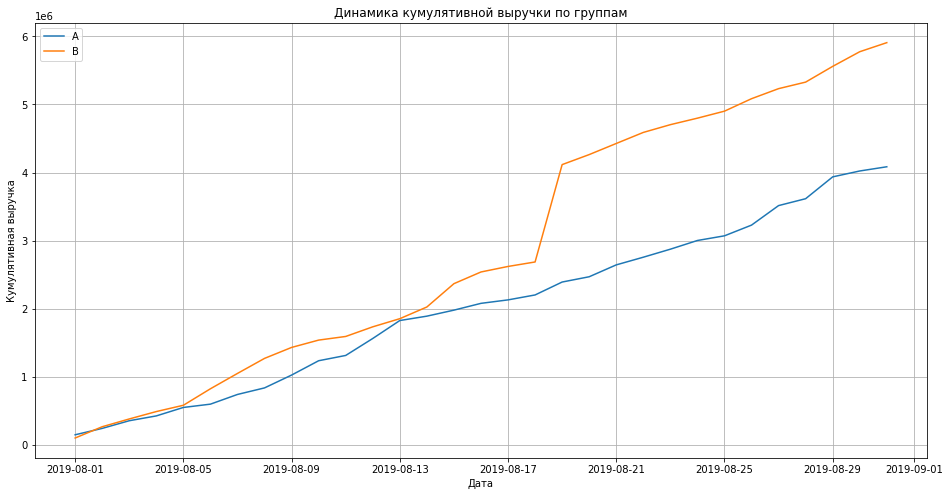

```python
# Задаем размер графика
plt.figure(figsize=(16, 8))

# Строим график выручки группы А
plt.plot(cumulativeRevenueA['date'], cumulativeRevenueA['revenue'], label='A')

# Строим график выручки группы B
plt.plot(cumulativeRevenueB['date'], cumulativeRevenueB['revenue'], label='B')

# Добавляем необходимые настройки к графику
plt.legend()
plt.grid()
plt.title('Динамика кумулятивной выручки по группам')
plt.xlabel('Дата')
plt.ylabel('Кумулятивная выручка')
plt.show()
```

**Вывод:**

По данному графику мы наблюдаем равномерный рост выручки в течение всего теста у обеих групп, также мы видим резкий скачок вурычки в середине августа у `группы B`, возможными причинами данного явления может быть резкий рост числа заказов или же появления очень дорогих заказов в выборке

## Построение графика кумулятивного среднего чека по группам

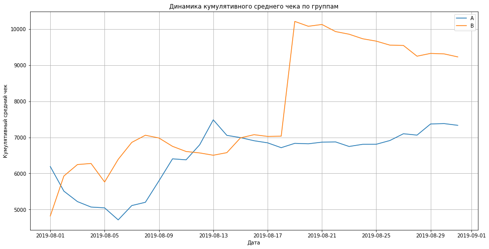

```python
# Задаем размер графика
plt.figure(figsize=(16, 8))

# Строим график для группы А
plt.plot(cumulativeRevenueA['date'], cumulativeRevenueA['revenue']/cumulativeRevenueA['orders'], label='A')

# Строим график для группы B
plt.plot(cumulativeRevenueB['date'], cumulativeRevenueB['revenue']/cumulativeRevenueB['orders'], label='B')

# Добавляем необходимые настройки к графику
plt.legend()
plt.grid()
plt.title('Динамика кумулятивного среднего чека по группам')
plt.xlabel('Дата')
plt.ylabel('Кумулятивный средний чек')
plt.show()
```

**Вывод:**

## Построение графика относительного изменения кумулятивного среднего чека группы B к группе A

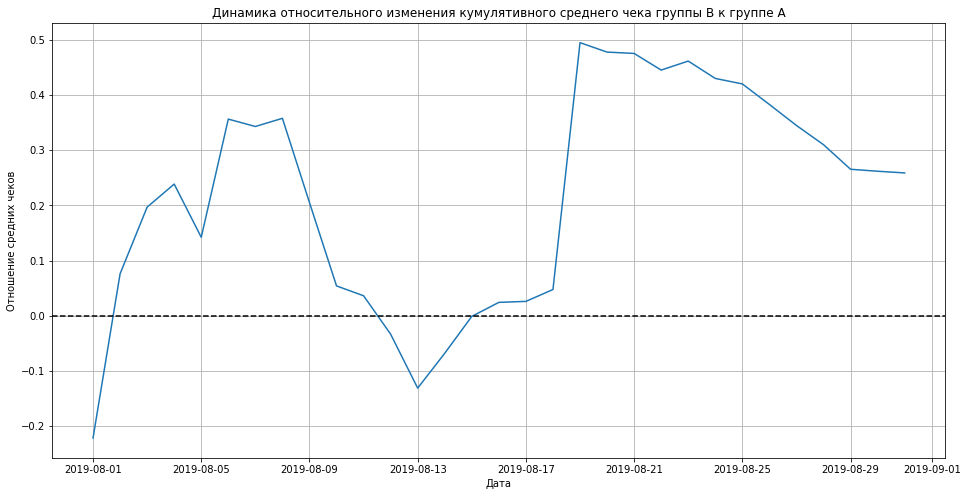

```python
# Собираем данные в одном датафрейме
mergedCumulativeRevenue = cumulativeRevenueA.merge ( cumulativeRevenueB,
                                                     left_on='date',
                                                     right_on='date',
                                                     how='left',
                                                     suffixes=['A', 'B'] )


# Задаем размер графика
plt.figure(figsize=(16, 8))

# Строим отношение средних чеков
plt.plot(mergedCumulativeRevenue["date"],
        (mergedCumulativeRevenue["revenueB"] / mergedCumulativeRevenue["ordersB"])
        / (mergedCumulativeRevenue["revenueA"] / mergedCumulativeRevenue["ordersA"]) - 1)

# Добавляем необходимые настройки к графику
plt.axhline(y=0, color="black", linestyle="--")
plt.grid()
plt.title('Динамика относительного изменения кумулятивного среднего чека группы B к группе A')
plt.xlabel('Дата')
plt.ylabel('Отношение средних чеков')
plt.show()
```

**Вывод:**

## Построение графика кумулятивного среднего количества заказов на посетителя (конверсии) по группам

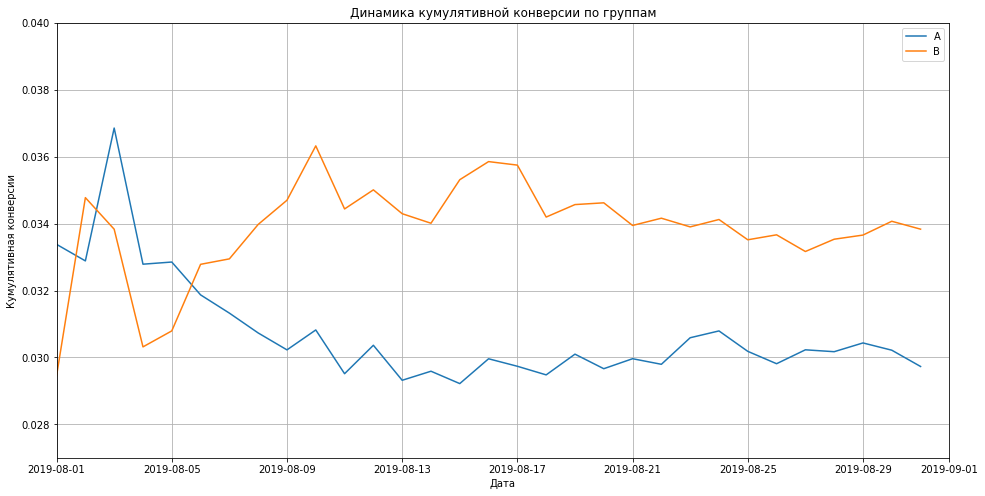

```python
# Считаем кумулятивную конверсию
cumulativeData['conversion'] = cumulativeData['orders']/cumulativeData['visitors']

# Отделяем данные по группе A
cumulativeDataA = cumulativeData[cumulativeData['group']=='A']

# Отделяем данные по группе B
cumulativeDataB = cumulativeData[cumulativeData['group']=='B']



# Задаем размер графика
plt.figure(figsize=(16, 8))

# Строим график для группы A
plt.plot(cumulativeDataA['date'], cumulativeDataA['conversion'], label='A')

# Строим график для группы B
plt.plot(cumulativeDataB['date'], cumulativeDataB['conversion'], label='B')


# Добавляем необходимые настройки к графику
plt.axis([dt.datetime(2019, 8, 1), dt.datetime(2019, 9, 1), 0.027, 0.04])
plt.legend()
plt.grid()
plt.title('Динамика кумулятивной конверсии по группам')
plt.xlabel('Дата')
plt.ylabel('Кумулятивная конверсии')
plt.show()
```

**Вывод:**

В начале теста обе группы показывают рост конверсии, затем `группа A` начинает стремительно падать и на протяжении всего теста остается на одном уровне, в то время как `группа B` показывает небольшой спад и затем дальнейший рост, оставаясь примерно на стабильно одинаковом уровне оставшийся промежуток теста, поэтому предварительно можем прийти к выводу, что конверсия `группы В` по результатам теста превышает конверсию `группы А`

## Построение графика относительного изменения кумулятивного среднего количества заказов на посетителя (конверсии) группы B к группе A

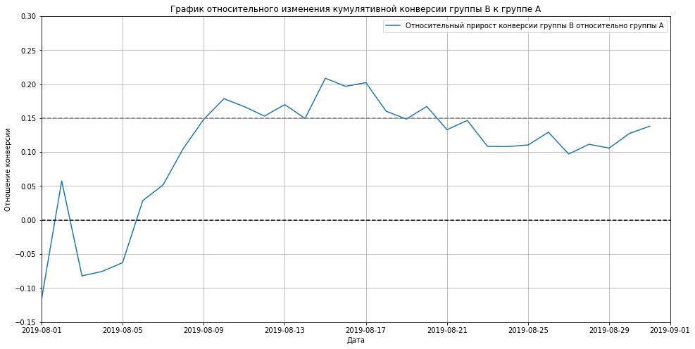

```python
# Для построение графика объединим 2 датафрейма
mergedCumulativeConversions = cumulativeDataA[['date','conversion']].merge(cumulativeDataB[['date','conversion']],
                                                                           left_on='date',
                                                                           right_on='date',
                                                                           how='left',
                                                                           suffixes=['A', 'B'])

# Задаем размер графика
plt.figure(figsize=(16, 8))

# Строим график
plt.plot(mergedCumulativeConversions["date"],
         mergedCumulativeConversions["conversionB"] / mergedCumulativeConversions["conversionA"]- 1,
         label="Относительный прирост конверсии группы B относительно группы A")


# Добавляем необходимые настройки к графику
plt.legend()
plt.grid()
plt.axhline(y=0, color='black', linestyle='--')
plt.axhline(y=0.15, color='grey', linestyle='--')
plt.axis([dt.datetime(2019, 8, 1), dt.datetime(2019, 9, 1), -0.15, 0.3])
plt.title('График относительного изменения кумулятивной конверсии группы B к группе A')
plt.xlabel('Дата')
plt.ylabel('Отношение конверсии')
plt.show()
```

**Вывод:**

По построенному графику, мы можем сделать вывод о том, что в первые дни теста `группа B` уступала контрольной группе, затем был небольшой рост, очередной спад до `5 августа` и после стремительный рост вплоть до `17 августа`, далее наблюдаем за небольшим спадом конверсии до самого окончания теста.

Стоит добавить, что отношение конверсии все еще не установилось, и пока рано делать какие-либо выводы по тесту. Поэтому, сперва следует проанализировать аномалии, возможно, поменяется картина.

## Построение точечного графика количества заказов по пользователям

Переде тем как строить график нам нужны необходимые данные. Для этого мы:

1. Сгруппируем заказы по пользователям;
2. Подсчитаем число уникальных заказов по сгруппированным данным, переименуем колонки и отсортируем датафрейм и выведем первые и последние 5 строк

```python
ordersByUsers = (orders.groupby('visitorId', as_index=False,).agg({'transactionId': 'nunique'}))
ordersByUsers.columns = ['user_id', 'orders']
ordersByUsers.sort_values(by='orders', ascending=False)
```

|  | user_id | orders |
| --- | --- | --- |
| 1023 | 4256040402 | 11 |
| 591 | 2458001652 | 11 |
| 569 | 2378935119 | 9 |
| 487 | 2038680547 | 8 |
| 44 | 199603092 | 5 |
| ... | ... | ... |
| 359 | 1484903144 | 1 |
| 360 | 1485964287 | 1 |
| 361 | 1494664757 | 1 |
| 362 | 1495112755 | 1 |
| 1030 | 4283872382 | 1 |

1031 rows × 2 columns

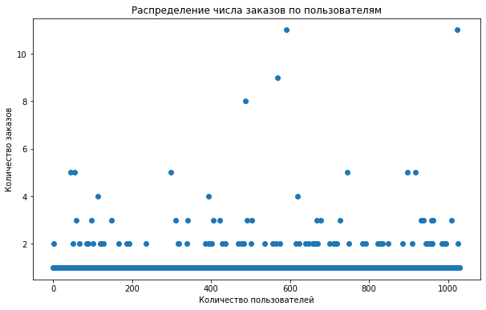

```python
# Запишем в переменную серию из чисел от 0 до количества наблюдений переменной ordersByUsers
x_values = pd.Series(range(0, len(ordersByUsers)))


# Задаем размер графика
plt.figure(figsize=(10, 6))

# Строим график
plt.scatter(x_values, ordersByUsers['orders'])

# Добавляем необходимые настройки к графику
plt.title('Распределение числа заказов по пользователям')
plt.xlabel('Количество пользователей')
plt.ylabel('Количество заказов')
plt.show()
```

**Вывод:**

Мы видим, что в основном пользователи делали до 2-х заказов, также видим, что есть небольшое кол-во людей, делавших более 2-х заказов, для того, чтобы оценить как много их, нужно будет посчитать выборочные перцентили

## Подсчет 95-ого и 99-ого перцентилей количества заказов на пользователя

```python
# Посчитаем выборочные перцентили количества заказов на одного пользователя
np.percentile(ordersByUsers['orders'], [95, 99])
```

```
array([2., 4.])
```

**Вывод:**

Теперь у нас есть понимание того, что только `5%` людей сделали больше 2-х заказов и только `1%` больше 4-х, поэтому в дальнейшем анализе будет целесообразно за нижнюю границу брать 2 заказа и по ней отсеять оставшиеся "аномальные" значения

## Построение точечного графика стоимостей заказов

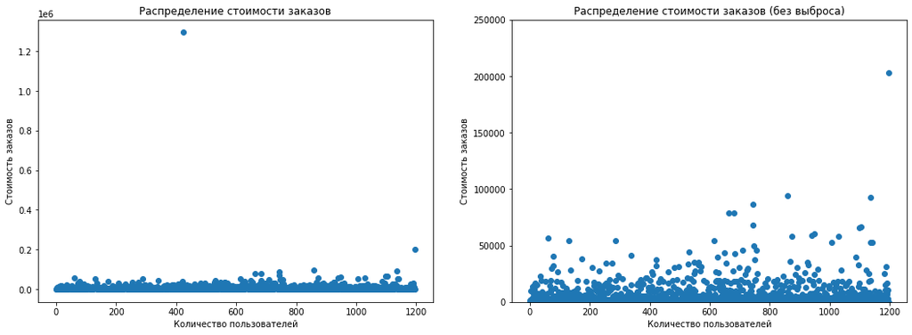

```python
x_values = pd.Series(range(0, len(orders['revenue'])))

# Строим точечный график стоимостей заказов с выбросами и без
fig, ax = plt.subplots(1,2, figsize=(18,6))
ax[0].scatter(x_values, orders['revenue'])
ax[1].scatter(x_values, orders['revenue'])


# Задаем необходимые настройки для каждого графика
ax[0].set_title('Распределение стоимости заказов')
ax[0].set_xlabel('Количество пользователей')
ax[0].set_ylabel('Стоимость заказов')
ax[1].set_title('Распределение стоимости заказов (без выброса)')
ax[1].set_xlabel('Количество пользователей')
ax[1].set_ylabel('Стоимость заказов')
ax[1].set_ylim(0,250000)

plt.show()
```

**Вывод:**

Судя по графику, подавляющее большинство пользователей сделали заказы до `30 тысяч у.е`, также есть заказы до `200 тыс. у.е` и даже более `1.2 млн у.е`

## Подсчет 95-ого и 99-ого перцентилей стоимости заказов

```python
# Посчитаем выборочные перцентили стоимости заказов
print(np.percentile(orders['revenue'], [95, 99]))
```

```
[28000.  58233.2]
```

**Вывод:**

Только `5%` пользователей сделали заказ на сумму более чем `28000 у.е` и только `1%` на сумму более чем `58233 у.е`, поэтому за нижнюю границу возьмем сумму в `28000 у.е`, все, что больше будем считать аномалией

## Подсчет статистической значимости различий в среднем количестве заказов на посетителя между группами по «сырым» данным

Прежде чем приступать к подсчету статистической значимости различий по "сырым" данным, нам следует собрать необходимые данные

```python
# Подготавливаем необходимые данные, которые нам понадобятся для анализа

visitorsADaily = visitors[visitors['group'] == 'A'][['date', 'visitors']]
visitorsADaily.columns = ['date', 'visitorsPerDateA']

visitorsACummulative = visitorsADaily.apply(
    lambda x: visitorsADaily[visitorsADaily['date'] <= x['date']].agg(
        {'date': 'max', 'visitorsPerDateA': 'sum'}
    ),
    axis=1,
)
visitorsACummulative.columns = ['date', 'visitorsCummulativeA']

visitorsBDaily = visitors[visitors['group'] == 'B'][['date', 'visitors']]
visitorsBDaily.columns = ['date', 'visitorsPerDateB']

visitorsBCummulative = visitorsBDaily.apply(
    lambda x: visitorsBDaily[visitorsBDaily['date'] <= x['date']].agg(
        {'date': 'max', 'visitorsPerDateB': 'sum'}
    ),
    axis=1,
)
visitorsBCummulative.columns = ['date', 'visitorsCummulativeB']

ordersADaily = (
    orders[orders['group'] == 'A'][['date', 'transactionId', 'visitorId', 'revenue']]
    .groupby('date', as_index=False)
    .agg({'transactionId': pd.Series.nunique, 'revenue': 'sum'})
)
ordersADaily.columns = ['date', 'ordersPerDateA', 'revenuePerDateA']

ordersACummulative = ordersADaily.apply(
    lambda x: ordersADaily[ordersADaily['date'] <= x['date']].agg(
        {'date': 'max', 'ordersPerDateA': 'sum', 'revenuePerDateA': 'sum'}
    ),
    axis=1,
).sort_values(by=['date'])
ordersACummulative.columns = [
    'date',
    'ordersCummulativeA',
    'revenueCummulativeA',
]

ordersBDaily = (
    orders[orders['group'] == 'B'][['date', 'transactionId', 'visitorId', 'revenue']]
    .groupby('date', as_index=False)
    .agg({'transactionId': pd.Series.nunique, 'revenue': 'sum'})
)
ordersBDaily.columns = ['date', 'ordersPerDateB', 'revenuePerDateB']

ordersBCummulative = ordersBDaily.apply(
    lambda x: ordersBDaily[ordersBDaily['date'] <= x['date']].agg(
        {'date': 'max', 'ordersPerDateB': 'sum', 'revenuePerDateB': 'sum'}
    ),
    axis=1,
).sort_values(by=['date'])
ordersBCummulative.columns = [
    'date',
    'ordersCummulativeB',
    'revenueCummulativeB',
]

data = (
    ordersADaily.merge(
        ordersBDaily, left_on='date', right_on='date', how='left'
    )
    .merge(ordersACummulative, left_on='date', right_on='date', how='left')
    .merge(ordersBCummulative, left_on='date', right_on='date', how='left')
    .merge(visitorsADaily, left_on='date', right_on='date', how='left')
    .merge(visitorsBDaily, left_on='date', right_on='date', how='left')
    .merge(visitorsACummulative, left_on='date', right_on='date', how='left')
    .merge(visitorsBCummulative, left_on='date', right_on='date', how='left')
)
```

Структура датафрейма `data`:

- `date` — дата;
- `ordersPerDateA` — количество заказов в выбранную дату в группе A;
- `revenuePerDateA` — суммарная выручка в выбранную дату в группе A;
- `ordersPerDateB` — количество заказов в выбранную дату в группе B;
- `revenuePerDateB` — суммарная выручка в выбранную дату в группе B;
- `ordersCummulativeA` — суммарное число заказов до выбранной даты включительно в группе A;
- `revenueCummulativeA` — суммарная выручка до выбранной даты включительно в группе A;
- `ordersCummulativeB` — суммарное количество заказов до выбранной даты включительно в группе B;
- `revenueCummulativeB` — суммарная выручка до выбранной даты включительно в группе B;
- `visitorsPerDateA` — количество пользователей в выбранную дату в группе A;
- `visitorsPerDateB` — количество пользователей в выбранную дату в группе B;
- `visitorsCummulativeA` — количество пользователей до выбранной даты включительно в группе A;
- `visitorsCummulativeB` — количество пользователей до выбранной даты включительно в группе B.

Посчитаем статистическую значимость различия в среднем количестве заказов между группами, создав две переменные, в которых будет общее количеству заказов у пользователей, которые сделали хотя бы 1 заказ

```python
# Расчет для группы A
ordersByUsersA = (
    orders[orders['group'] == 'A']
    .groupby('visitorId', as_index=False)
    .agg({'transactionId': pd.Series.nunique})
)
ordersByUsersA.columns = ['userId', 'orders']


# Расчет для группы B
ordersByUsersB = (
    orders[orders['group'] == 'B']
    .groupby('visitorId', as_index=False)
    .agg({'transactionId': pd.Series.nunique})
)
ordersByUsersB.columns = ['userId', 'orders']
```

Для проверки выборки по `критерию Уилкоксона-Манна-Уитни` объявим переменные `sampleA` и `sampleB`, в которых пользователям из разных групп будет соответствовать количество заказов, тем, кто ничего не заказал, будут соответствовать нули

```python
sampleA = pd.concat([ordersByUsersA['orders'],
                     pd.Series(0, index=np.arange(data['visitorsPerDateA'].sum() - len(ordersByUsersA['orders'])),
                     name='orders')],
                     axis=0)

sampleB = pd.concat([ordersByUsersB['orders'],
                     pd.Series(0, index=np.arange(data['visitorsPerDateB'].sum() - len(ordersByUsersB['orders'])),
                     name='orders')],
                     axis=0)
```

Сформулируем гипотезы и проверим их:

- **H₀ (нулевая гипотеза)** - различий в среднем количестве заказов между группами нет;
- **H₁ (альтернативная гипотеза)** - различия в среднем количестве заказов между группами есть

```python
sampleA = pd.concat(
    [
        ordersByUsersA['orders'],
        pd.Series(
            0,
            index=np.arange(
                data['visitorsPerDateA'].sum() - len(ordersByUsersA['orders'])
            ),
            name='orders',
        ),
    ],
    axis=0,
)

sampleB = pd.concat(
    [
        ordersByUsersB['orders'],
        pd.Series(
            0,
            index=np.arange(
                data['visitorsPerDateB'].sum() - len(ordersByUsersB['orders'])
            ),
            name='orders',
        ),
    ],
    axis=0,
)

print('p-value:')
print("{0:.3f}".format(stats.mannwhitneyu(sampleA, sampleB)[1]))
print()
print('Относительное различие в среднем кол-ве заказов между группами:')
print("{0:.3f}".format(sampleB.mean() / sampleA.mean() - 1))
```

[output not shown]

**Вывод:**

`p-value` = `0.017` и оно меньше `0.05`, а это значит, что в конверсии между группами есть статистически значимые различия, поэтому мы отвергаем нулевую гипотезу (относительное различие конверсии `группы В` к конверсии `группы А` равен `13.8%`

## Подсчет статистической значимости различий в среднем чеке заказа между группами по «сырым» данным

Сформулируем гипотезы и проверим их:

- **H₀ (нулевая гипотеза)** - различий в среднем чеке между группами нет;
- **H₁ (альтернативная гипотеза)** - различия в среднем чеке между группами есть

Чтобы рассчитать статистическую значимость различий в среднем чеке, передадим критерию `mannwhitneyu()` данные о выручке с заказов.

```python
print('p-value:')
print('{0:.3f}'.format(stats.mannwhitneyu(orders[orders['group']=='A']['revenue'], orders[orders['group']=='B']['revenue'])[1]))
print()
print('Относительное различие в среднем чеке между группами:')
print('{0:.3f}'.format(orders[orders['group']=='B']['revenue'].mean()/orders[orders['group']=='A']['revenue'].mean()-1))
```

```
p-value:
0.729

Относительное различие в среднем чеке между группами:
0.259
```

**Вывод:**

`p-value` = `0.729`, что гораздо больше заданного нами порога в `0.05`, поэтому мы не будем отвергать нулевую гипотезу.  
Также, стоит отметить, что относительное различие в среднем чеке между группами составляет `25.9%`, что довольно-таки много, возможно на полученный результат повлияли "аномалии".

## Подсчет статистической значимости различий в среднем количестве заказов на посетителя между группами по «очищенным» данным

Прежде чем приступать к анализу, нам нужны "очищенные" данные.

Ранее мы определили нижние границы для "аномальных" значений, поэтому все, что выше `2-х заказов` и стоимости `28 тысяч у.е` будем считать "аномальным". Отфильтруем и узнаем сколько всего таких пользователей

```python
usersWithManyOrders = pd.concat(
    [
        ordersByUsersA[ordersByUsersA['orders'] > 2]['userId'],
        ordersByUsersB[ordersByUsersB['orders'] > 2]['userId'],
    ],
    axis=0,
)
usersWithExpensiveOrders = orders[orders['revenue'] > 28000]['visitorId']
abnormalUsers = (
    pd.concat([usersWithManyOrders, usersWithExpensiveOrders], axis=0)
    .drop_duplicates()
    .sort_values()
)

print(f'Вывод: всего {abnormalUsers.shape[0]} "аномальных" пользователей')
```

```
Вывод: всего 74 "аномальных" пользователей
```

Узнаем, как их действия повлияли на результаты теста. Посчитаем статистическую значимость различий в среднем количестве заказов между группами теста по очищенным данным. Сначала подготовим выборки количества заказов по пользователям по группам теста:

```python
sampleAFiltered = pd.concat(
    [
        ordersByUsersA[
            np.logical_not(ordersByUsersA['userId'].isin(abnormalUsers))
        ]['orders'],
        pd.Series(
            0,
            index=np.arange(
                data['visitorsPerDateA'].sum() - len(ordersByUsersA['orders'])
            ),
            name='orders',
        ),
    ],
    axis=0,
)

sampleBFiltered = pd.concat(
    [
        ordersByUsersB[
            np.logical_not(ordersByUsersB['userId'].isin(abnormalUsers))
        ]['orders'],
        pd.Series(
            0,
            index=np.arange(
                data['visitorsPerDateB'].sum() - len(ordersByUsersB['orders'])
            ),
            name='orders',
        ),
    ],
    axis=0,
)
```

Применим статистический `критерий Уилкоксона-Манна-Уитни` к полученным выборкам:

```python
print('p-value:')
print('{0:.3f}'.format(stats.mannwhitneyu(sampleAFiltered, sampleBFiltered)[1]))
print()
print('Относительное различие в среднем количестве заказов между группами:')
print('{0:.3f}'.format(sampleBFiltered.mean()/sampleAFiltered.mean()-1))
```

```
p-value:
0.013

Относительное различие в среднем количестве заказов между группами:
0.173
```

**Вывод:**

Как и в "сырых" данных `p-value` меньше `0.05`, поэтому мы тоже отвергаем нулевую гипотезу.

Также стоит отметить, что относительный прирост конверсии очищенной `группы B` к конверсии `группы А` увеличился на `3.5%` (по сравнению с "сырыми" данными) и равен `17.3%`

## Подсчет статистической значимости различий в среднем чеке заказа между группами по «очищенным» данным

```python
print('p-value:')
print(
    '{0:.3f}'.format(
        stats.mannwhitneyu(
            orders[
                np.logical_and(
                    orders['group'] == 'A',
                    np.logical_not(orders['visitorId'].isin(abnormalUsers)),
                )
            ]['revenue'],
            orders[
                np.logical_and(
                    orders['group'] == 'B',
                    np.logical_not(orders['visitorId'].isin(abnormalUsers)),
                )
            ]['revenue'],
            True, # что бы задать 4ый параметр
            'two-sided' # для двух-стороннего теста
        )[1]
    )
)
print()
print('Относительное различие в среднем чеке между группами:')
print(
    "{0:.3f}".format(
        orders[
            np.logical_and(
                orders['group'] == 'B',
                np.logical_not(orders['visitorId'].isin(abnormalUsers)),
            )
        ]['revenue'].mean()
        / orders[
            np.logical_and(
                orders['group'] == 'A',
                np.logical_not(orders['visitorId'].isin(abnormalUsers)),
            )
        ]['revenue'].mean()
        - 1
    )
)
```

```
p-value:
0.738

Относительное различие в среднем чеке между группами:
-0.020
```

**Вывод:**

По сравнению с "сырыми" данными `P-value` увеличился, поэтому нулевая гипотеза не отвергается.

При этом относительное различие `группы В` к `группе А`, после очистки от "аномалий" данных снизилось на `27.9%`, и составляет всего `2%` в пользу `группы А`.

## Принятие решения по результатам теста

По результатам `A/B-теста` мы приняли решение `остановить тест` и признать его успешным, зафиксировав победу `группы B`, так как:

- мы выявили статистически значимое различие по конверсии между группами как по "сырым" данным, так и по "очищенным";
- конверсия `группы B` увеличилась по сравнению с `группой A`, но при этом статистически значимых различий в среднем чеке заказа между группами нет.

# Вывод

В ходе исследоваания данных по увеличению выручки в интернет-магазине мы:

1. Провели обзор и предобработку входных данных;
2. Приоритизировали гипотезы, использовав фреймворки `ICE` и `RICE`:
- После применения фреймворка `ICE` наиболее приоритетными гипотезами являются:

```
- Запустить акцию, дающую скидку на товар в день рождения (Гипотеза № 8)
- Добавить два новых канала привлечения трафика, что позволит привлекать на 30% больше пользователей (Гипотеза № 0)
- Добавить форму подписки на все основные страницы, чтобы собрать базу клиентов для email-рассылок (Гипотеза № 7)
- Показать на главной странице баннеры с актуальными акциями и распродажами, чтобы увеличить конверсию (Гипотеза № 6)
- Добавить блоки рекомендаций товаров на сайт интернет магазина, чтобы повысить конверсию и средний чек заказа (Гипотеза №2)
```

- После применения фреймворка `RICE` наиболее приоритетными гипотезами являются:

```
- Добавить форму подписки на все основные страницы, чтобы собрать базу клиентов для email-рассылок (Гипотеза № 7)
- Добавить блоки рекомендаций товаров на сайт интернет магазина, чтобы повысить конверсию и средний чек заказа (Гипотеза № 2)
- Добавить два новых канала привлечения трафика, что позволит привлекать на 30% больше пользователей (Гипотеза № 0)
- Показать на главной странице баннеры с актуальными акциями и распродажами, чтобы увеличить конверсию (Гипотеза № 6)
- Запустить акцию, дающую скидку на товар в день рождения (Гипотеза № 8)
```

1. Провели A/B тест:
- была посчитана статистическая значимость различий между группами по «сырым» и «очищенным» данным;
- посчитана 95 и 99 перцентили для количества заказов и среднего чека (аномалией считалось более `2-х заказов` и стоимость более `28000 у.е`)
- по результату A/B теста мы приняли решение его остановить и признать успешным, даже несмотря на то, что по среднему чеку статистической значимости не обнаружено, так как мы выявили статистически значимое различие по конверсии между группами как в "сырых" так и "очищенных" от аномалий данных, что напрямую влияет на выручку.